# Task 6.4

Hannes Guth

2022-11-20

## Data exploration

Before the actual regression task, the data needs to be explored. The following packages will be needed throughout the document.

```r
library(naniar) # package for missing value analysis
library(data.table) # package for handling data in a datatable
library(caret) # package includes function RMSE
library(Hmisc) # package includes function cut2
library(forecast) # package for the function predict
```

The dataset is loaded first.

```r
corolla <- fread("ToyotaCorolla.csv") # read the dataset into a datatable
set.seed(1) # for reproducability
```

The actual exploration begins with the dimensions of the dataset.

```r
dim(corolla) # gives the dimensions of corolla
```

```
## [1] 1436   39
```

This dataset has 1436 observation and 39 variables.

It will be examined in what form the values of the single variables are.

```r
str(corolla)
```

```
## Classes 'data.table' and 'data.frame':   1436 obs. of  39 variables:
##  $ Id               : int  1 2 3 4 5 6 7 8 9 10 ...
##  $ Model            : chr  "TOYOTA Corolla 2.0 D4D HATCHB TERRA 2/3-Doors" "TOYOTA Corolla 2.0 D4D HATCHB TERRA 2/3-Doors" "\xa0TOYOTA Corolla 2.0 D4D HATCHB TERRA 2/3-Doors" "TOYOTA Corolla 2.0 D4D HATCHB TERRA 2/3-Doors" ...
##  $ Price            : int  13500 13750 13950 14950 13750 12950 16900 18600 21500 12950 ...
##  $ Age_08_04        : int  23 23 24 26 30 32 27 30 27 23 ...
##  $ Mfg_Month        : int  10 10 9 7 3 1 6 3 6 10 ...
##  $ Mfg_Year         : int  2002 2002 2002 2002 2002 2002 2002 2002 2002 2002 ...
##  $ KM               : int  46986 72937 41711 48000 38500 61000 94612 75889 19700 71138 ...
##  $ Fuel_Type        : chr  "Diesel" "Diesel" "Diesel" "Diesel" ...
##  $ HP               : int  90 90 90 90 90 90 90 90 192 69 ...
##  $ Met_Color        : int  1 1 1 0 0 0 1 1 0 0 ...
##  $ Color            : chr  "Blue" "Silver" "Blue" "Black" ...
##  $ Automatic        : int  0 0 0 0 0 0 0 0 0 0 ...
##  $ CC               : int  2000 2000 2000 2000 2000 2000 2000 2000 1800 1900 ...
##  $ Doors            : int  3 3 3 3 3 3 3 3 3 3 ...
```

[output cut: 26 more lines]

The missing values-analysis will be made using gg_miss_var.

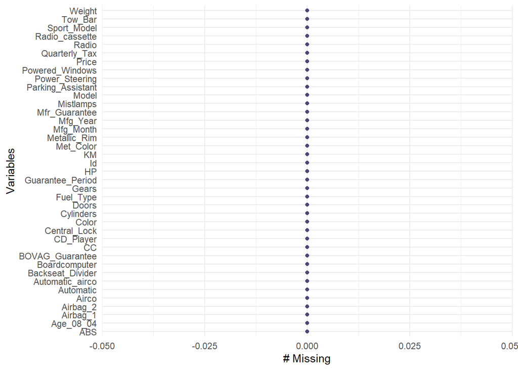

```r
gg_miss_var(corolla)
```

There are no missing values in this dataset.

The prices will be considered to be EUR in the whole analysis.

## Data preparation

In order to conduct further analysis, here regression, a few variables first must be converted to dummy variables.  
This applies to Fuel_Type and Doors.

```r
# Dummy variables

corolla$Fuel_Type_Diesel <- ifelse(corolla$Fuel_Type == 'Diesel', 1, 0) # if the fuel type is Diesel, set the value of this observation in the new dummy variable column of Diesel to 1, else to 0
corolla$Fuel_Type_Petrol <- ifelse(corolla$Fuel_Type == 'Petrol', 1, 0) # same approach for petrol
# CNG will not get a new dummy-variable column because it is a linear combination of the two newly created dummy variable columns
corolla$Doors2 <- ifelse(corolla$Doors == 2, 1, 0) # same approach
corolla$Doors3 <- ifelse(corolla$Doors == 3, 1, 0) # same approach
corolla$Doors4 <- ifelse(corolla$Doors == 4, 1, 0) # same approach
```

The next step is to partition the data into training, validation and test sets (50:30:20).

```r
# Splitting

trainingIndex = sample(seq_len(nrow(corolla)), size = 0.5*nrow(corolla)) # trainingIndex gets 60% of the indices of the initial dataset
training = corolla[trainingIndex,] # the corresponding data to trainingindex are loaded into training
rest = corolla[-trainingIndex,] # the rest of the data is assigned to rest

validationIndex = sample(seq_len(nrow(rest)), size = 0.6*nrow(rest)) # 60% of the rest indices are assigned to calidationIndex
validation = corolla[validationIndex,] # the values of these 60% are assigned to validation
test = corolla[-validationIndex,] # the values that have not been assigned to validation are assigned to test
```

According to the task, only selected variables shall be used to execute further analyses. This will be done in the following.

```r
variables <- c("Price", "Age_08_04", "KM", "Fuel_Type_Diesel", "Fuel_Type_Petrol", "HP", "Automatic", "Doors2", "Doors3", "Doors4", "Quarterly_Tax", "Mfr_Guarantee", "Guarantee_Period", "Airco", "Automatic_airco", "CD_Player", "Powered_Windows", "Sport_Model", "Tow_Bar") # setting the variables on which the regression shall be executed
training = training[, ..variables] # reducing the initial dataset to these variables
```

## Linear Model

A multiple linear regression model will be created as follows.

```r
corollaModel <- lm(Price ~ ., data = training) # run a multiple linear model to predict price based on all other variables of training
options(scipen = 999) # turn off scientific notation
summary(corollaModel) # output the summary of the linear model
```

```
##
## Call:
## lm(formula = Price ~ ., data = training)
##
## Residuals:
##     Min      1Q  Median      3Q     Max
## -5217.3  -738.5   -57.4   662.2  7103.4
##
## Coefficients:
##                      Estimate   Std. Error t value             Pr(>|t|)
## (Intercept)      10577.229313   786.684871  13.445 < 0.0000000000000002 ***
## Age_08_04         -107.891048     4.098047 -26.327 < 0.0000000000000002 ***
## KM                  -0.018635     0.001874  -9.944 < 0.0000000000000002 ***
## Fuel_Type_Diesel  2223.203927   527.242449   4.217          0.000028054 ***
## Fuel_Type_Petrol  1373.469986   548.868366   2.502             0.012564 *
## HP                  39.218982     4.421124   8.871 < 0.0000000000000002 ***
## Automatic          491.634855   230.808243   2.130             0.033515 *
## Doors2             951.688339  1269.825195   0.749             0.453830
## Doors3            -390.497024   105.114306  -3.715             0.000219 ***
## Doors4            -439.332154   173.407748  -2.534             0.011510 *
## Quarterly_Tax       13.135732     2.449435   5.363          0.000000112 ***
## Mfr_Guarantee      255.863049   101.368831   2.524             0.011821 *
## Guarantee_Period    76.300929    18.226233   4.186          0.000031971 ***
## Airco              198.387075   121.392461   1.634             0.102654
## Automatic_airco   3185.375869   236.570487  13.465 < 0.0000000000000002 ***
## CD_Player          474.194764   132.065081   3.591             0.000353 ***
## Powered_Windows    386.258219   118.090893   3.271             0.001125 **
## Sport_Model        506.160752   110.800178   4.568          0.000005814 ***
## Tow_Bar           -244.213699   112.829301  -2.164             0.030767 *
## ---
## Signif. codes:  0 '***' 0.001 '**' 0.01 '*' 0.05 '.' 0.1 ' ' 1
##
## Residual standard error: 1258 on 699 degrees of freedom
## Multiple R-squared:  0.888,  Adjusted R-squared:  0.8851
## F-statistic: 307.8 on 18 and 699 DF,  p-value: < 0.00000000000000022
```

Obviously, there are several variables that appear highly significant. Also one can see that the multiple R-squared and the adjusted R-squared, both are approximately 89%.

This model will now be used to predict the prices of the validation set.

```r
predictPrices <- predict(corollaModel, validation) # predict prices of the validation set
accuracy(predictPrices, validation$Price) # calculate the accuracy of the predictions, comparing them to the true prices
```

```
##                 ME     RMSE     MAE       MPE     MAPE
## Test set -178.5325 1420.355 1053.19 -3.115964 9.027437
```

The RMSE is 1420.

## a)

### What appear to be the three or four most important car specifications for predicting the car’s price?

A simple approach would be to take the features with the smallest p-values of the summary in the previous page. This would be Age, KM, HP and automatic air-condition.

In the second approach, the varImp function from the caret package will be used.

```r
importance <- varImp(corollaModel, scale = FALSE) # getting the variable importance using varImp
importance$Overall <- sort(importance$Overall, decreasing = TRUE) # sort the importance of the variables
importance # output the importance
```

```
##                     Overall
## Age_08_04        26.3274291
## KM               13.4648067
## Fuel_Type_Diesel  9.9436165
## Fuel_Type_Petrol  8.8708180
## HP                5.3627605
## Automatic         4.5682305
## Doors2            4.2166634
## Doors3            4.1863247
## Doors4            3.7149751
## Quarterly_Tax     3.5906143
## Mfr_Guarantee     3.2708553
## Guarantee_Period  2.5335209
## Airco             2.5240801
## Automatic_airco   2.5023668
## CD_Player         2.1644528
## Powered_Windows   2.1300576
## Sport_Model       1.6342619
## Tow_Bar           0.7494641
```

Another approach is to use forward and backward selection. This will be carried out in the following.

```r
forwModel <- train(Price ~ ., data = training, # train the model to predict Price on all the other variables from training
                   method = "leapForward", # Forward selection
                   tuneGrid = data.frame(nvmax = 3:4), # number of predictors is 3-4
                   trControl = trainControl(method = "cv", number = 10)) # set how train will compute, cv splits the data into number (10) folds
```

```
## Reordering variables and trying again:
```

```r
# same approach but with leapBackward instead of leapForward
backwModel <- train(Price ~ ., data = training,
                   method = "leapBackward",
                   tuneGrid = data.frame(nvmax = 3:4),
                   trControl = trainControl(method = "cv", number = 10))
```

```
## Reordering variables and trying again:
```

```r
# return the 4 predictors from both approaches for the forward model
coef(forwModel$finalModel, 4)
```

```
##     (Intercept)       Age_08_04              HP   Quarterly_Tax Automatic_airco
##     13007.13647      -144.14391        45.35270        11.34114      3628.21521
```

```r
# return the 4 predictors from both approaches for the backward model
coef(backwModel$finalModel, 4)
```

```
##     (Intercept)       Age_08_04              HP   Quarterly_Tax Automatic_airco
##     13007.13647      -144.14391        45.35270        11.34114      3628.21521
```

The result from above does not go in line with the findings from the forward and backward selection. Both selection methods deliver age, HP, quarterly tax and automatic aircondition as the four most important variables.

```r
# calculate the models with the 4 variables that were obtained from the two different methods above

corollaModelpValue <- lm(Price ~ Age_08_04 + KM + HP + Automatic_airco, data = training) # for the varImp function


corollaModelVarImp <- lm(Price ~ Age_08_04 + KM + Fuel_Type_Diesel + Fuel_Type_Petrol, data = training) # for the varImp function

corollaModelForwBackw <- lm(Price ~ Age_08_04 + HP + Quarterly_Tax + Automatic_airco, data = training) # for the forward/backward selection

predictPricespValue <- predict(corollaModelpValue, validation) # do the prediction for model with the variables from the selection methods

predictPricesVarImp <- predict(corollaModelVarImp, validation) # do the prediction for model with the variables from the varImp method

predictPricesForwBackw <- predict(corollaModelForwBackw, validation) # do the prediction for model with the variables from the selection methods

# calculating the RMSE for the approaches
RMSE(predictPricespValue, validation$Price)
```

```
## [1] 1705.018
```

```r
RMSE(predictPricesVarImp, validation$Price)
```

```
## [1] 2135.952
```

```r
RMSE(predictPricesForwBackw, validation$Price)
```

```
## [1] 1622.577
```

The selection model performs best in terms of RMSE and will therefore be taken as the comparison to the big model for b).

## b)

### Using metrics you consider useful, assess the performance of the model in predicting prices.

This task will be done graphically and using metrics. Also, the performance of the model with all variables will be compared to the performance of the selection model with only 4 variables.

#### Graphically

At first, both models’ performances will be assessed in two boxplots.

The data will organised in a datatable, first.

```r
# organising

accuracyb <- data.table("TruePrice" = validation$Price, "PredictionAllVar" = predictPrices, "PredictionSelectionMeth" = predictPricesForwBackw) # new data.table with the most relevant rows of validation and the predicted prices

accuracyb$DistAll <- accuracyb$TruePrice - accuracyb$PredictionAllVar # set a new column with the difference between price and the predictions of the big model

accuracyb$DistSelection <- accuracyb$TruePrice - accuracyb$PredictionSelectionMeth # set a new column with the difference between price and the predictions of the model with the selection methods
```

Here, the boxplots are created.

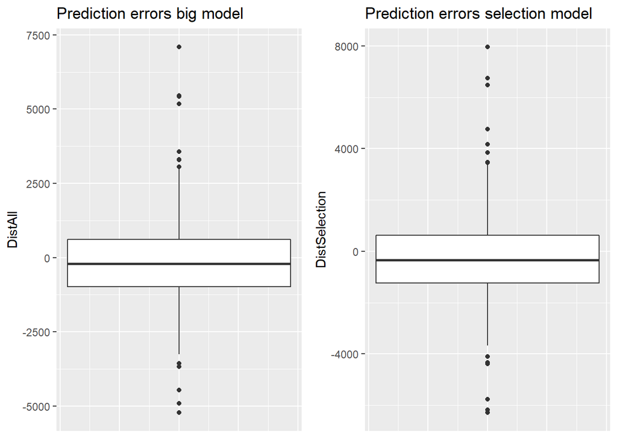

```r
# boxplots

# plot this distance as a barplot
allPlot <- ggplot(accuracyb, aes(y=DistAll)) +
  geom_boxplot() +
  labs(title = "Prediction errors big model") + # set the title
  theme(axis.title.x = element_blank(), # empty x-axis
       axis.text.x = element_blank(),
       axis.ticks.x = element_blank())

selectionPlot <- ggplot(accuracyb, aes(y=DistSelection)) +
  geom_boxplot() +
  labs(title = "Prediction errors selection model") + # set the title
  theme(axis.title.x = element_blank(), # empty x-axis
         axis.text.x = element_blank(),
         axis.ticks.x = element_blank())
require(gridExtra) # needed for combining two ggplots
grid.arrange(allPlot, selectionPlot, ncol=2) # combine both ggplots that were created above
```

```r
# calculate the mean and median of the errors
median(accuracyb$DistAll)
```

```
## [1] -206.7898
```

```r
mean(accuracyb$DistAll)
```

```
## [1] -178.5325
```

```r
median(accuracyb$DistSelection)
```

```
## [1] -342.3761
```

```r
mean(accuracyb$DistSelection)
```

```
## [1] -300.8746
```

Both boxplots look nearly identical but since the pot of the selection model has a bigger y-scale, the errors are more distracted and further away from 0 than in the big model.  
Both boxplots have a median and mean slightly below 0, the selection model a bit stronger. Since error terms should have an expectation of 0, one can conclude that the model is flawed, here, but not seriously since there is the values are close to 0.

```r
cor(abs(accuracyb$DistAll), accuracyb$TruePrice) # calculate correlation between the error of the big model and the true price to learn if the absolute error increases with price
```

```
## [1] 0.2180827
```

```r
cor(abs(accuracyb$DistSelection), accuracyb$TruePrice) # calculate correlation between the error of the selection model and the true price to learn if the absolute error increases with price
```

```
## [1] 0.1426006
```

The absolute value of the error terms for both models is not strongly correlated with the absolute price, so one cannot state that the error are getting larger with a rising price.

In the following, the errors will be categorised in groups of magnitudes of the specific errors. Then, the categorised data will be shown in a line graph in order to learn about the distribution of error magnitudes of the two models.

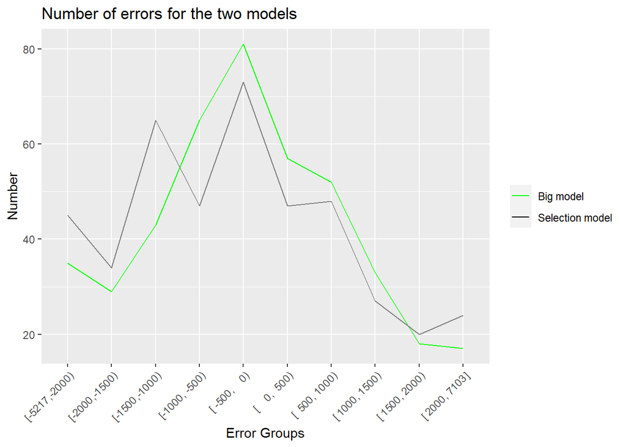

```r
# separate the errors of the two models into categories, each consisting of an interval of 500
accuracyb$DistGroupsAll <- cut2(accuracyb$DistAll, cuts = c(-2000, -1500, -1000, -500, 0, 500, 1000, 1500, 2000))
accuracyb$DistGroupsSelection <- cut2(accuracyb$DistSelection, cuts = c(-2000, -1500, -1000, -500, 0, 500, 1000, 1500, 2000))

# count the errors for each category for both models
# create a new datatable for that
errorPlotTable <- data.table((accuracyb[, .N, by = DistGroupsAll])[order(rank(DistGroupsAll), N)]) # for the big model
errorPlotTable$NSelection <- data.table((accuracyb[, .N, by = DistGroupsSelection])[order(rank(DistGroupsSelection), N)])$N # for the selection model

ggplot(errorPlotTable, aes(DistGroupsAll, group = 1)) + # new ggplot with the data of errorPlotTable
  geom_path(aes(y=N), colour = "green") + # add a line for the big model
  geom_path(aes(y=NSelection, colour = "black")) + # add a line for the selection model
  scale_color_manual("",
                     values = c("Big model" = "green", "Selection model" = "black")) + # set colours
  labs(title = "Number of errors for the two models", y = "Number", x = "Error Groups") + # set title and axis descriptions
  theme(axis.text.x=element_text(angle=45, hjust=1)) # rotate the x-axis labels
```

The big model has visibly higher numbers of predictions in the area of smaller errors. The larger the distance to the true price (the bigger the error), the more observations can be seen from the selection model. This goes in line with the finding, that the selection model has a higher RMSE than the big model.

#### Metrics

In the next section, it will be examined how well the two models will perform, considering different statistical metrics.

```r
accuracy(predictPrices, validation$Price) # calculate the accuracy
```

```
##                 ME     RMSE     MAE       MPE     MAPE
## Test set -178.5325 1420.355 1053.19 -3.115964 9.027437
```

```r
accuracy(predictPricesForwBackw, validation$Price) # calculate the accuracy
```

```
##                 ME     RMSE      MAE      MPE     MAPE
## Test set -300.8746 1622.577 1210.472 -4.96408 10.66137
```

The mean error of the big model is closer to 0 than the one of the small model, but both are slightly negative. The RMSE is with 1420 about 200 smaller than for the small model. The same applies for he mean absolute error, which is 1053 for the big model. According to MPE, the predictions of the big model were 3.11% below the true value. For the small model, it were 4.96%. The Mean Absolute Percentage Error is for the big model 9.02% and for the small model 10.66%.

#### Conclusion

After these analyses, it seems that the big model outperforms the smaller one. This is counter-intuitive because it was to expect that including so many variables would lead to over-fitting and that a small model should solve this problem. Cutting out so many variables obviously led to not only cancelling out over-fitting but also explanatory power.

## References

### Packages

Tierney N, Cook D, McBain M, Fay C (2021). *naniar: Data Structures, Summaries, and Visualisations for Missing Data*. R package version 0.6.1, https://CRAN.R-project.org/package=naniar.

Dowle M, Srinivasan A (2021). *data.table: Extension of `data.frame`*. R package version 1.14.2, https://CRAN.R-project.org/package=data.table.

Kuhn M (2022). *caret: Classification and Regression Training*. R package version 6.0-93, https://CRAN.R-project.org/package=caret.

Harrell Jr F (2022). *Hmisc: Harrell Miscellaneous*. R package version 4.7-1, https://CRAN.R-project.org/package=Hmisc.

Hyndman R, Athanasopoulos G, Bergmeir C, Caceres G, Chhay L, O’Hara-Wild M, Petropoulos F, Razbash S, Wang E, Yasmeen F (2022). *forecast: Forecasting functions for time series and linear models*. R package version 8.18, https://pkg.robjhyndman.com/forecast/.

Hyndman RJ, Khandakar Y (2008). “Automatic time series forecasting: the forecast package for R.” *Journal of Statistical Software*, *26*(3), 1-22. doi:10.18637/jss.v027.i03 https://doi.org/10.18637/jss.v027.i03.